# Report Selection

Esmeralda García Legarda

2022-06-14

## Statistical Models and Bioinformatics Tools

**Summary of the results:**

The secondary structures are those predicted by PSI-PRED. They will be based on the 3D-structure soon.

[figure not shown]

### Phylogeny

This is the phylogeny used to apply the different methods. Previously, I ran Jmodeltest2 with an alignment of the whole genomes to know which could be the best model and, as a result, the tree was generated with TIM2+I+G and bootstrap = 100.

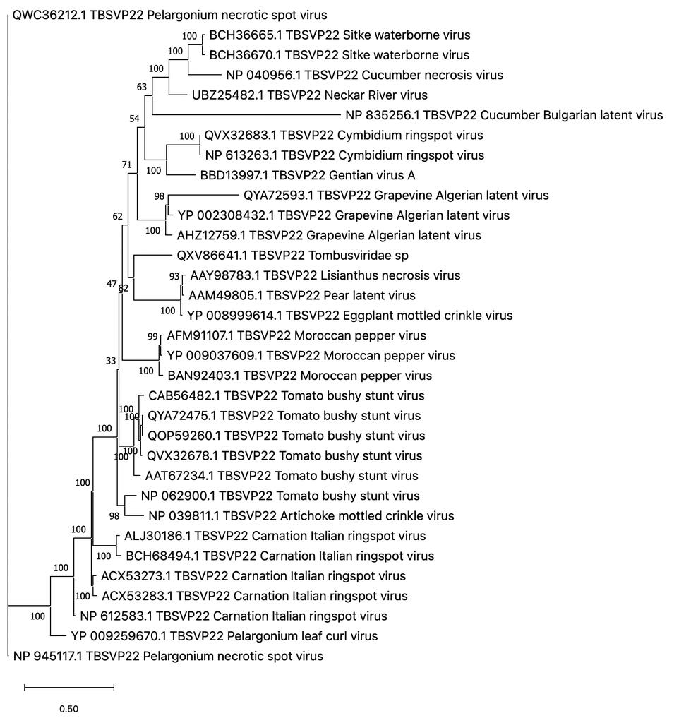

### Individual Site Models AND co-evolution methods: P22

#### FEL

FEL (Fixed EffectsLikelihood) uses a maximum-likelihood (ML) approach to infer nonsynoymous (dN) and synonymous (dS) substitution rates on a per-site basis for a given coding alignment and corresponding phylogeny. This method assumes that the selection pressure for each site is constant along the entire phylogeny.

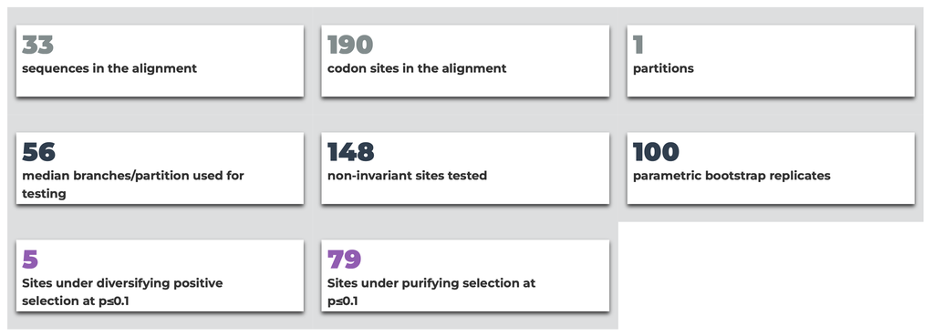

[figure not shown]

```r
FEL.all <- read.csv(file = "/Users/esmeralda/Documents/TFM/RevTrans/programmes/FEL/codons.csv", sep = ",", header = TRUE)
DT::datatable(FEL.all,
              rownames = FEL.all$Codon,
              caption = "Table 1. Detailed site-by-site results from the FEL analysis. Site classification at p<=0.1")
```

| Codon | Partition | alpha | beta | LRT | Selection.detected. | dN.dS.with.confidence.intervals |
| --- | --- | --- | --- | --- | --- | --- |
| 9 | 1 | 908 | 0 | 4165 | Neg. p = 0.0198 | 0.000( 0.00- 0.26) |
| 10 | 1 | 479 | 0 | 2860 | Neg. p = 0.0594 | 0.000( 0.00- 0.59) |
| 72 | 1 | 479 | 0 | 2860 | Neg. p = 0.0594 | 0.000( 0.00- 0.59) |
| 22 | 1 | 367 | 0 | 2284 | Neg. p = 0.0693 | 0.000( 0.00- 0.90) |
| 4 | 1 | 475 | 0 | 2784 | Neg. p = 0.0297 | 0.000( 0.00- 0.63) |
| 8 | 1 | 707 | 0 | 4228 | Neg. p = 0.0198 | 0.000( 0.00- 0.51) |
| 17 | 1 | 1060 | 0 | 5614 | Neg. p = 0.0297 | 0.000( 0.00- 0.29) |
| 28 | 1 | 1921 | 0 | 8519 | Neg. p = 0.0099 | 0.000( 0.00- 0.12) |
| 2 | 1 | 1759 | 0 | 8033 | Neg. p = 0.0099 | 0.000( 0.00- 0.15) |
| 32 | 1 | 1843 | 0 | 8661 | Neg. p = 0.0099 | 0.000( 0.00- 0.18) |

[output cut: 77 more lines]

alpha: Synonymous substitution rate at a site beta: Non-synonymous substitution rate at a site alpha=beta: The rate estimate under the neutral model LRT: Likelihood ratio test statistic for beta = alpha, versus beta &neq; alpha p-value: Asymptotic p-value for evidence of selection, i.e. beta &neq; alpha

#### FUBAR

FUBAR (Fast, UnconstrainedBayesian AppRoximation) uses a Bayesian approach to infer nonsynoymous (dN) and synonymous (dS) substitution rates on a per-site basis for a given coding alignment and corresponding phylogeny. This method assumes that the selection pressure for each site is constant along the entire phylogeny.

FUBAR found evidence of (+) pervasive positive/diversifying selection at 6 sites and (-) pervasive negative/purifying selection at 75 sites with posterior probability of 0.9.

```r
FUBAR.all <- read.csv(file = "/Users/esmeralda/Documents/TFM/RevTrans/programmes/FUBAR/datamonkey-table.csv", sep = ",", header = TRUE)
DT::datatable(FUBAR.all,
              colnames = c("Site","Partition","α","β","β-α","Prob[α>β]","Prob[α<β]","BayesFactor[α<β]"),
              rownames = FUBAR.all$Site,
              caption = "Table 1. Detailed site-by-site results from the FUBAR analysis. Evidence with posterior probability of 0.9")
```

| Site | Partition | α | β | β-α | Prob[α>β] | Prob[α<β] | BayesFactor[α<β] |
| --- | --- | --- | --- | --- | --- | --- | --- |
| 1 | 1 | 3.947 | 0.106 | -3.84 | 0.887 | 0.071 | 0.139 |
| 2 | 1 | 3.817 | 0.115 | -3.701 | 0.987 | 0.009 | 0.017 |
| 3 | 1 | 0.393 | 0.145 | -0.248 | 0.696 | 0.204 | 0.47 |
| 4 | 1 | 0.779 | 0.157 | -0.621 | 0.898 | 0.073 | 0.144 |
| 5 | 1 | 3.578 | 0.155 | -3.424 | 0.977 | 0.016 | 0.03 |
| 6 | 1 | 0.398 | 0.782 | 0.384 | 0.169 | 0.783 | 6.616 |
| 7 | 1 | 0.404 | 0.182 | -0.222 | 0.66 | 0.245 | 0.594 |
| 8 | 1 | 1.046 | 0.18 | -0.865 | 0.934 | 0.048 | 0.092 |
| 9 | 1 | 1.467 | 0.126 | -1.341 | 0.946 | 0.037 | 0.071 |
| 10 | 1 | 0.784 | 0.15 | -0.634 | 0.904 | 0.068 | 0.133 |

[output cut: 180 more lines]

alpha: Mean posterior synonymous substitution rate at a site beta: Mean posterior non-synonymous substitution rate at a site beta-alpha: mean posterior beta-alpha Prob[alpha>beta]: Posterior probability of negative selection at a site Prob[alpha<beta]: Posterior probability of positive selection at a site BayesFactor[alpha<beta]: Empiricial Bayes Factor for positive selection at a site

#### SLAC

SLAC (Single-Likelihood Ancestor Counting) uses a combination of maximum-likelihood (ML) and counting approaches to infer nonsynonymous (dN) and synonymous (dS) substitution rates on a per-site basis for a given coding alignment and corresponding phylogeny. Like FEL, this method assumes that the selection pressure for each site is constant along the entire phylogeny.

SLAC found evidence of pervasive

(+) positive/diversifying selection at 2 sites

(-) negative/purifying selection at 59 sites

with p-value threshold of 0.1.

```r
SLAC.all <- read.csv(file = "/Users/esmeralda/Documents/TFM/RevTrans/programmes/SLAC/data.csv", sep = ";", header = TRUE)
DT::datatable(SLAC.all,
              rownames = SLAC.all$Codon,
              caption = "Table 1. Detailed site-by-site results from the SLAC analysis. Site classification at p<=0.1")
```

| Codon | Partition | S | N | dS | dN | Selection.detected. |
| --- | --- | --- | --- | --- | --- | --- |
| 2 | 1 | 2 | 0 | 3.754 | 0 | Neg. p = 0.032 |
| 5 | 1 | 2 | 0 | 3.905 | 0 | Neg. p = 0.042 |
| 14 | 1 | 5 | 0 | 6.913 | 0 | Neg. p = 0.001 |
| 15 | 1 | 7 | 0 | 4.885 | 0 | Neg. p = 0.006 |
| 17 | 1 | 2 | 0 | 2.611 | 0 | Neg. p = 0.073 |
| 18 | 1 | 3 | 1 | 4.718 | 0.449 | Neg. p = 0.037 |
| 25 | 1 | 6 | 0 | 4.069 | 0 | Neg. p = 0.014 |
| 28 | 1 | 2 | 0 | 3.909 | 0 | Neg. p = 0.029 |
| 30 | 1 | 3 | 0 | 3 | 0 | Neg. p = 0.038 |
| 32 | 1 | 3 | 0 | 3.953 | 0 | Neg. p = 0.018 |

[output cut: 51 more lines]

#### MEME

MEME (Mixed EffectsModel of Evolution) employs a mixed-effects maximum likelihood approach to test the hypothesis that individual sites have been subject to episodic positive or diversifying selection. In other words, MEME aims to detect sites evolving under positive selection under a proportion of branches.

MEME found evidence of (+) episodic positive/diversifying selection at 12 sites with p-value threshold of 0.1.

```r
MEME.all <- read.csv(file = "/Users/esmeralda/Documents/TFM/RevTrans/programmes/MEME/datamonkey-table.csv", sep = ",", header = TRUE)
DT::datatable(MEME.all,
              colnames = c("Site","Partition","α","β-", "p-","β+","p+", "LTR","p-value", "# branches under selection", "Total branch length ","MEME logL","FEL logL"),
              rownames = MEME.all$Site,
              caption = "Table 1. Detailed site-by-site results from the MEME analysis. Evidence with posterior probability of 0.9")
```

| Site | Partition | α | β- | p- | β+ | p+ | LTR | p-value | # branches under selection | Total branch length | MEME logL | FEL logL |
| --- | --- | --- | --- | --- | --- | --- | --- | --- | --- | --- | --- | --- |
| 1 | 1 | 0 | 0 | 1 | 0 | 0 | 0 | 1 | 0 | 0 | 0 | 0 |
| 2 | 1 | 1.85 | 0 | 1 | 2.77 | 0 | 0 | 0.67 | 0 | 0 | -10.06 | -10.06 |
| 3 | 1 | 0 | 0 | 1 | 0 | 0 | 0 | 1 | 0 | 0 | 0 | 0 |
| 4 | 1 | 0.42 | 0 | 1 | 0.63 | 0 | 0 | 0.67 | 0 | 0 | -6.17 | -6.17 |
| 5 | 1 | 1.79 | 0 | 1 | 2.69 | 0 | 0 | 0.67 | 0 | 0 | -8.97 | -8.97 |
| 6 | 1 | 0 | 0 | 0 | 0.44 | 1 | 1.89 | 0.19 | 3 | 0 | -19.08 | -19.08 |
| 7 | 1 | 0 | 0 | 1 | 0 | 0 | 0 | 1 | 0 | 0 | 0 | 0 |
| 8 | 1 | 0.58 | 0 | 1 | 0.87 | 0 | 0 | 0.67 | 0 | 0 | -11.62 | -11.62 |
| 9 | 1 | 0.81 | 0 | 1 | 1.21 | 0 | 0 | 0.67 | 0 | 0 | -6.69 | -6.69 |
| 10 | 1 | 0.41 | 0 | 1 | 0.62 | 0 | 0 | 0.67 | 0 | 0 | -6.24 | -6.24 |

[output cut: 180 more lines]

#### BGM

The Bayesian Graphical Model (BGM) method is a tool for detecting coevolutionary interactions between amino acid positions in a protein. This method is similar to the “correlated substitutions” method described by Shindyalov et al. 1994, in which amino acid substitution events are mapped to branches in the phylogenetic tree. BGM uses a method similar to SLAC, where amino acid substitution events are mapped to the tree from the ancestral reconstruction under joint maximum likelihood for a given model of codon substitution rates.

BGM found 18 pairs of co-evolving sites (posterior probability >= 0.5), 2 pairs of co-evolving sites (posterior probability >= 0.9).

```r
BGM.all <- read.csv(file = "/Users/esmeralda/Documents/TFM/RevTrans/programmes/BGM/datamonkey-table.csv", sep = ",", header = TRUE)
DT::datatable(BGM.all,
              colnames = c("Site 1","Site 2","P[Site 1 –> Site 2]","P [Site 2 –> Site 1]", "P[Site 1 <–> Site 2]","Site 1 subs","Site 2 subs", "Shared subs"),
              rownames = BGM.all$Site,
              caption = "Table 1. Detailed site-by-site results from the BGM analysis.Evidence with posterior probability of 0.5")
```

| Site 1 | Site 2 | P[Site 1 –> Site 2] | P [Site 2 –> Site 1] | P[Site 1 <–> Site 2] | Site 1 subs | Site 2 subs | Shared subs |
| --- | --- | --- | --- | --- | --- | --- | --- |
| 19 | 129 | 0.12 | 0.87 | 0.99 | 7 | 6 | 6 |
| 34 | 146 | 0.54 | 0.003 | 0.55 | 7 | 5 | 4 |
| 36 | 87 | 0.48 | 0.4 | 0.88 | 2 | 2 | 2 |
| 38 | 129 | 0 | 0.53 | 0.53 | 4 | 6 | 4 |
| 45 | 171 | 0.23 | 0.29 | 0.52 | 1 | 1 | 1 |
| 50 | 97 | 0.028 | 0.69 | 0.72 | 6 | 4 | 4 |
| 58 | 143 | 0.31 | 0.34 | 0.65 | 4 | 4 | 4 |
| 58 | 154 | 0.24 | 0.36 | 0.59 | 4 | 4 | 4 |
| 64 | 149 | 0.34 | 0.34 | 0.69 | 2 | 2 | 2 |
| 97 | 117 | 0.62 | 0.16 | 0.78 | 4 | 5 | 4 |

[output cut: 8 more lines]

#### Summary

These results include sites which were obtained at least by two methods.

```r
fubar.sig <- FUBAR.all$Site[FUBAR.all$Prob..alpha...beta.. > 0.9 | FUBAR.all$Prob..alpha...beta...1 > 0.9]
meme.sig <- MEME.all$Site[MEME.all$p.value < 0.1]

inter1 <- intersect(FEL.all$Codon, SLAC.all$Codon)
inter2 <- intersect(MEME.all$Site[MEME.all$p.value < 0.1], SLAC.all$Codon)
inter3 <- intersect(MEME.all$Site[MEME.all$p.value < 0.1], FEL.all$Codon)
inter4 <- intersect(fubar.sig, FEL.all$Codon)
inter5 <- intersect(fubar.sig, SLAC.all$Codon)
inter6 <- intersect(fubar.sig, MEME.all$Site[MEME.all$p.value < 0.1])

sites <- sort(Reduce(union, list(inter1, inter2, inter3, inter4, inter5, inter6)))
sites
```

```
##  [1]   2   5   8   9  10  14  15  17  18  21  25  28  30  32  34  35  38  42  43
## [20]  53  54  55  56  57  59  60  62  63  65  72  74  84  86  88  89  91  93  97
## [39] 101 103 104 105 107 108 111 112 113 115 116 117 123 126 130 131 133 138 139
## [58] 146 150 152 155 157 158 160 164 165 168 169 170 172 174 176 178 179 189
```

```r
length(sites)
```

```
## [1] 75
```

### Individual Site Models AND co-evolution methods: P19

#### FEL

FEL (Fixed EffectsLikelihood) uses a maximum-likelihood (ML) approach to infer nonsynoymous (dN) and synonymous (dS) substitution rates on a per-site basis for a given coding alignment and corresponding phylogeny. This method assumes that the selection pressure for each site is constant along the entire phylogeny.

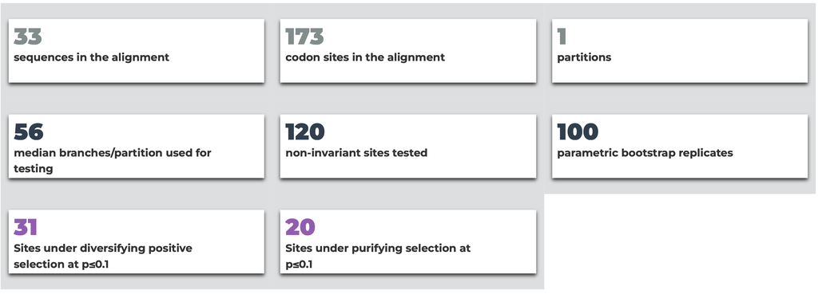

[figure not shown]

```r
FEL.all <- read.csv(file = "/Users/esmeralda/Documents/TFM/RevTrans/programmes_over/FEL/data.csv", sep = ";", header = TRUE)
DT::datatable(FEL.all,
              rownames = FEL.all$Codon,
              caption = "Table 1. Detailed site-by-site results from the FEL analysis. Site classification at p<=0.1")
```

| Codon | Partition | alpha | beta | LRT | Selection.detected. | dN.dS.with.confidence.intervals |
| --- | --- | --- | --- | --- | --- | --- |
| 36 | 1 | 2.328 | 0 | 3.83 | Neg. p = 0.0198 | 0.000( 0.00- 0.32) |
| 2 | 1 | 5.876 | 0 | 7.66 | Neg. p = 0.0099 | 0.000( 0.00- 0.14) |
| 27 | 1 | 0 | 2.508 | 3.048 | Pos. p = 0.0891 | 10000.000(6810.32-10000.00) |
| 10 | 1 | 0 | 2.236 | 2.879 | Pos. p = 0.0891 | 10000.000(6186.60-10000.00) |
| 4 | 1 | 0 | 5.901 | 6.889 | Pos. p = 0.0099 | 10000.000(8078.18-10000.00) |
| 28 | 1 | 0 | 2.203 | 2.851 | Pos. p = 0.0693 | 10000.000(6186.60-10000.00) |
| 25 | 1 | 0 | 4.541 | 4.816 | Pos. p = 0.0396 | 10000.000(7600.10-10000.00) |
| 43 | 1 | 4.369 | 0.478 | 4.704 | Neg. p = 0.0396 | 0.109( 0.01- 0.51) |
| 16 | 1 | 0 | 3.303 | 3.028 | Pos. p = 0.0891 | 10000.000(7260.52-10000.00) |
| 48 | 1 | 1.353 | 0 | 2.678 | Neg. p = 0.0693 | 0.000( 0.00- 0.66) |

[output cut: 34 more lines]

alpha: Synonymous substitution rate at a site beta: Non-synonymous substitution rate at a site alpha=beta: The rate estimate under the neutral model LRT: Likelihood ratio test statistic for beta = alpha, versus beta &neq; alpha p-value: Asymptotic p-value for evidence of selection, i.e. beta &neq; alpha

#### FUBAR

FUBAR (Fast, UnconstrainedBayesian AppRoximation) uses a Bayesian approach to infer nonsynoymous (dN) and synonymous (dS) substitution rates on a per-site basis for a given coding alignment and corresponding phylogeny. This method assumes that the selection pressure for each site is constant along the entire phylogeny.

FUBAR found evidence of (+) pervasive positive/diversifying selection at 38 sites and (-) pervasive negative/purifying selection at 14 sites with posterior probability of 0.9.

```r
FUBAR.all <- read.csv(file = "/Users/esmeralda/Documents/TFM/RevTrans/programmes_over/FUBAR/datamonkey-table.csv", sep = ",", header = TRUE)
DT::datatable(FUBAR.all,
              colnames = c("Site","Partition","α","β","β-α","Prob[α>β]","Prob[α<β]","BayesFactor[α<β]"),
              rownames = FUBAR.all$Site,
              caption = "Table 1. Detailed site-by-site results from the FUBAR analysis. Evidence with posterior probability of 0.9")
```

| Site | Partition | α | β | β-α | Prob[α>β] | Prob[α<β] | BayesFactor[α<β] |
| --- | --- | --- | --- | --- | --- | --- | --- |
| 1 | 1 | 2.938 | 0.136 | -2.803 | 0.762 | 0.139 | 0.161 |
| 2 | 1 | 3.122 | 0.197 | -2.925 | 0.963 | 0.026 | 0.026 |
| 3 | 1 | 0.251 | 0.279 | 0.028 | 0.417 | 0.442 | 0.793 |
| 4 | 1 | 0.313 | 3.288 | 2.975 | 0.001 | 0.997 | 296.533 |
| 5 | 1 | 0.433 | 0.759 | 0.326 | 0.199 | 0.75 | 3 |
| 6 | 1 | 0.377 | 0.182 | -0.194 | 0.609 | 0.26 | 0.351 |
| 7 | 1 | 0.335 | 1.031 | 0.697 | 0.101 | 0.864 | 6.357 |
| 8 | 1 | 2.425 | 2.128 | -0.298 | 0.338 | 0.471 | 0.891 |
| 9 | 1 | 0.763 | 0.915 | 0.153 | 0.301 | 0.619 | 1.628 |
| 10 | 1 | 0.369 | 1.243 | 0.874 | 0.083 | 0.884 | 7.659 |

[output cut: 163 more lines]

alpha: Mean posterior synonymous substitution rate at a site beta: Mean posterior non-synonymous substitution rate at a site beta-alpha: mean posterior beta-alpha Prob[alpha>beta]: Posterior probability of negative selection at a site Prob[alpha<beta]: Posterior probability of positive selection at a site BayesFactor[alpha<beta]: Empiricial Bayes Factor for positive selection at a site

#### SLAC

SLAC (Single-Likelihood Ancestor Counting) uses a combination of maximum-likelihood (ML) and counting approaches to infer nonsynonymous (dN) and synonymous (dS) substitution rates on a per-site basis for a given coding alignment and corresponding phylogeny. Like FEL, this method assumes that the selection pressure for each site is constant along the entire phylogeny.

SLAC found evidence of pervasive

(+) positive/diversifying selection at 11 sites

(-) negative/purifying selection at 12 sites

with p-value threshold of 0.1.

```r
SLAC.all <- read.csv(file = "/Users/esmeralda/Documents/TFM/RevTrans/programmes_over/SLAC/data.csv", sep = ";", header = TRUE)
DT::datatable(SLAC.all,
              rownames = SLAC.all$Codon,
              caption = "Table 1. Detailed site-by-site results from the SLAC analysis. Site classification at p<=0.1")
```

| X.....Codon | Partition | S | N | dS | dN | Selection.detected. |
| --- | --- | --- | --- | --- | --- | --- |
| 2 | 1 | 2 | 0 | 3.262 | 0 | Neg. p = 0.045 |
| 4 | 1 | 0 | 9 | 0 | 4.474 | Pos. p = 0.027 |
| 15 | 1 | 5 | 7 | 9.019 | 2.899 | Neg. p = 0.056 |
| 40 | 1 | 0 | 14 | 0 | 6.179 | Pos. p = 0.025 |
| 43 | 1 | 4 | 1 | 3.719 | 0.523 | Neg. p = 0.060 |
| 49 | 1 | 0 | 11 | 0 | 5.389 | Pos. p = 0.019 |
| 50 | 1 | 0 | 11 | 0 | 4.529 | Pos. p = 0.098 |
| 51 | 1 | 0 | 11 | 0 | 5.705 | Pos. p = 0.015 |
| 81 | 1 | 0 | 6 | 0 | 3 | Pos. p = 0.088 |
| 83 | 1 | 7 | 0 | 5.129 | 0 | Neg. p = 0.007 |

[output cut: 13 more lines]

#### MEME

MEME (Mixed EffectsModel of Evolution) employs a mixed-effects maximum likelihood approach to test the hypothesis that individual sites have been subject to episodic positive or diversifying selection. In other words, MEME aims to detect sites evolving under positive selection under a proportion of branches.

MEME found evidence of (+) episodic positive/diversifying selection at 39 sites with p-value threshold of 0.1.

```r
MEME.all <- read.csv(file = "/Users/esmeralda/Documents/TFM/RevTrans/programmes_over/MEME/datamonkey-table.csv", sep = ",", header = TRUE)
DT::datatable(MEME.all,
              colnames = c("Site","Partition","α","β-", "p-","β+","p+", "LTR","p-value", "# branches under selection", "Total branch length ","MEME logL]","FEL logL"),
              rownames = MEME.all$Site,
              caption = "Table 1. Detailed site-by-site results from the MEME analysis. Evidence with posterior probability of 0.9")
```

| Site | Partition | α | β- | p- | β+ | p+ | LTR | p-value | # branches under selection | Total branch length | MEME logL] | FEL logL |
| --- | --- | --- | --- | --- | --- | --- | --- | --- | --- | --- | --- | --- |
| 1 | 1 | 0 | 0 | 1 | 0 | 0 | 0 | 1 | 0 | 0 | 0 | 0 |
| 2 | 1 | 5.91 | 0 | 1 | 8.86 | 0 | 0 | 0.67 | 0 | 0 | -13.7 | -13.7 |
| 3 | 1 | 0 | 0 | 1 | 0 | 0 | 0 | 1 | 0 | 0 | 0 | 0 |
| 4 | 1 | 0 | 0 | 0.49 | 13.81 | 0.51 | 9.03 | 0 | 3 | 0 | -36.15 | -35.07 |
| 5 | 1 | 0 | 0 | 0 | 1.41 | 1 | 1.18 | 0.29 | 2 | 0 | -17.93 | -17.93 |
| 6 | 1 | 0 | 0 | 1 | 0 | 0 | 0 | 1 | 0 | 0 | 0 | 0 |
| 7 | 1 | 0 | 0 | 0.88 | 22.49 | 0.12 | 8.16 | 0.01 | 2 | 0 | -17.81 | -15.16 |
| 8 | 1 | 4.34 | 3.32 | 1 | 6.5 | 0 | 0 | 0.67 | 0 | 0 | -31.54 | -31.54 |
| 9 | 1 | 1.9 | 0.63 | 0.98 | 1484.11 | 0.02 | 9.1 | 0 | 1 | 0 | -33.1 | -28.56 |
| 10 | 1 | 0 | 0 | 0 | 2.23 | 1 | 2.88 | 0.11 | 3 | 0 | -20.25 | -20.25 |

[output cut: 163 more lines]

#### BGM

The Bayesian Graphical Model (BGM) method is a tool for detecting coevolutionary interactions between amino acid positions in a protein. This method is similar to the “correlated substitutions” method described by Shindyalov et al. 1994, in which amino acid substitution events are mapped to branches in the phylogenetic tree. BGM uses a method similar to SLAC, where amino acid substitution events are mapped to the tree from the ancestral reconstruction under joint maximum likelihood for a given model of codon substitution rates.

BGM found 18 pairs of co-evolving sites (posterior probability >= 0.5), 2 pairs of co-evolving sites (posterior probability >= 0.9).

```r
BGM.all <- read.csv(file = "/Users/esmeralda/Documents/TFM/RevTrans/programmes/BGM/datamonkey-table.csv", sep = ",", header = TRUE)
DT::datatable(BGM.all,
              colnames = c("Site 1","Site 2","P[Site 1 –> Site 2]","P [Site 2 –> Site 1]", "P[Site 1 <–> Site 2]","Site 1 subs","Site 2 subs", "Shared subs"),
              rownames = BGM.all$Site,
              caption = "Table 1. Detailed site-by-site results from the BGM analysis. Evidence with posterior probability of 0.5")
```

| Site 1 | Site 2 | P[Site 1 –> Site 2] | P [Site 2 –> Site 1] | P[Site 1 <–> Site 2] | Site 1 subs | Site 2 subs | Shared subs |
| --- | --- | --- | --- | --- | --- | --- | --- |
| 19 | 129 | 0.12 | 0.87 | 0.99 | 7 | 6 | 6 |
| 34 | 146 | 0.54 | 0.003 | 0.55 | 7 | 5 | 4 |
| 36 | 87 | 0.48 | 0.4 | 0.88 | 2 | 2 | 2 |
| 38 | 129 | 0 | 0.53 | 0.53 | 4 | 6 | 4 |
| 45 | 171 | 0.23 | 0.29 | 0.52 | 1 | 1 | 1 |
| 50 | 97 | 0.028 | 0.69 | 0.72 | 6 | 4 | 4 |
| 58 | 143 | 0.31 | 0.34 | 0.65 | 4 | 4 | 4 |
| 58 | 154 | 0.24 | 0.36 | 0.59 | 4 | 4 | 4 |
| 64 | 149 | 0.34 | 0.34 | 0.69 | 2 | 2 | 2 |
| 97 | 117 | 0.62 | 0.16 | 0.78 | 4 | 5 | 4 |

[output cut: 8 more lines]

#### Summary

These results include sites which were obtained at least by two methods.

```r
fubar.sig <- FUBAR.all$Site[FUBAR.all$Prob..alpha...beta.. > 0.9 | FUBAR.all$Prob..alpha...beta...1 > 0.9]
meme.sig <- MEME.all$Site[MEME.all$p.value < 0.1]

inter1 <- intersect(FEL.all$Codon, SLAC.all$Codon)
inter2 <- intersect(MEME.all$Site[MEME.all$p.value < 0.1], SLAC.all$Codon)
inter3 <- intersect(MEME.all$Site[MEME.all$p.value < 0.1], FEL.all$Codon)
inter4 <- intersect(fubar.sig, FEL.all$Codon)
inter5 <- intersect(fubar.sig, SLAC.all$Codon)
inter6 <- intersect(fubar.sig, MEME.all$Site[MEME.all$p.value < 0.1])

sites <- sort(Reduce(union, list(inter1, inter2, inter3, inter4, inter5, inter6)))
sites
```

```
##  [1]   2   4  15  16  25  27  36  40  43  47  49  50  51  64  74  78  81  83  91
## [20]  92  93  94  97 101 105 106 107 108 119 121 123 128 134 135 142 145 148 149
## [39] 150 154 155 159 160 164 166
```

```r
length(sites)
```

```
## [1] 45
```